# Clean Waters — Nearshore Chl-a and ratio excess

## 5.5 Full-period trend table (2000–2024)

```r
trend_table <- regional_ratio %>%
  group_by(rgn_id, rgn_num) %>%
  summarize(
    slope_mg_yr = coef(lm(ratio_excess ~ year))[2],
    p_value = summary(lm(ratio_excess ~ year))$coefficients[2, 4],
    mean_2000_2004 = mean(ratio_excess[year <= early_period_end], na.rm = TRUE),
    mean_2019_2024 = mean(ratio_excess[year >= 2019], na.rm = TRUE),
    .groups = "drop"
  ) %>%
  mutate(
    change_early_to_recent = mean_2019_2024 - mean_2000_2004,
    trend = if_else(p_value < 0.05 & slope_mg_yr > 0, "Increasing (p < 0.05)",
             if_else(p_value < 0.05 & slope_mg_yr < 0, "Decreasing (p < 0.05)",
                      "Not significant"))
  ) %>%
  arrange(desc(slope_mg_yr))

knitr::kable(trend_table %>% select(rgn_id, slope_mg_yr, p_value,
                                    mean_2000_2004, mean_2019_2024,
                                    change_early_to_recent, trend),
             digits = 3,
             caption = "Full-period ratio excess trends with early vs recent means")
```

Full-period ratio excess trends with early vs recent means

| rgn_id | slope_mg_yr | p_value | mean_2000_2004 | mean_2019_2024 | change_early_to_recent | trend |
| --- | --- | --- | --- | --- | --- | --- |
| Region_9 | 0.045 | 0.009 | -0.855 | 0.077 | 0.932 | Increasing (p < 0.05) |
| Region_8 | 0.040 | 0.028 | -0.946 | -0.160 | 0.786 | Increasing (p < 0.05) |
| Region_7 | 0.022 | 0.009 | -0.499 | 0.073 | 0.572 | Increasing (p < 0.05) |
| Region_6 | 0.014 | 0.038 | -0.303 | 0.086 | 0.388 | Increasing (p < 0.05) |
| Region_3 | 0.012 | 0.021 | -0.261 | 0.029 | 0.290 | Increasing (p < 0.05) |
| Region_2 | 0.011 | 0.029 | -0.179 | -0.019 | 0.160 | Increasing (p < 0.05) |
| Region_5 | 0.010 | 0.007 | -0.152 | 0.082 | 0.234 | Increasing (p < 0.05) |
| Region_1 | -0.004 | 0.172 | 0.136 | 0.034 | -0.102 | Not significant |
| Region_4 | -0.005 | 0.083 | 0.051 | -0.106 | -0.157 | Not significant |

## 5.6 Example map — ratio excess, 2020

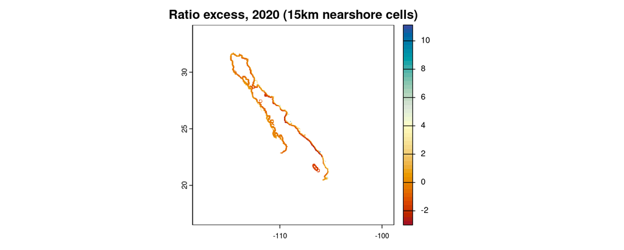

```r
ratio_2020 <- rast(file.path(dir_ratio, "ratio_excess_2020.tif"))
plot(
  ratio_2020,
  main = sprintf("Ratio excess, 2020 (%s nearshore cells)", nearshore_tag),
  col = hcl.colors(50, "RdYlBu"),
  range = global(ratio_2020, range, na.rm = TRUE)$range
)
```

# Summary

| Step | What we did |
| --- | --- |
| 1 | Loaded Copernicus 4 km monthly Chl-a (2000–2024) |
| 2 | Defined **15 km nearshore** and **offshore** zones per OHI region |
| 3 | Showed raw nearshore/offshore **co-vary** — simple contrast is not enough |
| 4 | Computed **ratio excess** = `near − R_ref × off` with $R_{\text{ref}}$ from **2000–2024** |
| 5 | Gulf-wide and **per-region** comparison plots; trend sensitivity for early years |

**Trend interpretation:** Several regions had **negative** ratio excess in 2000–2004. Full-period positive trends partly reflect a shift from that low early period to higher recent values — check **Section 5.4** before using trend slope alone as pressure.

**Outputs on Mazu** (15km nearshore band):

- `chla_int/masks/15km/`
- `chla_int/ratio_excess_15km/annual/ratio_excess_YYYY.tif`
- `chla_int/ratio_excess_15km/reference/R_ref_near_off_ratio_2000_2024.csv`

**Next steps (not in this notebook):**

- Rescale ratio excess or its trend to 0–1 **pressure** for OHI Clean Waters
- Validate against nitrogen loading (`cw_eutrophication.qmd`) and known input coasts
- Compare alternative reference windows for $R_{\text{ref}}$

*Input rasters: `step1_cw_chla.qmd`. Earlier exploratory work: `check_cw_chla.qmd`, `chla_restart.Rmd`.*